# APS 3

ana flavia arrym

2024-04-08

#Organização dos dados

```r
#Baixando bibliotecas
library(tidyverse)
```

```r
library(dplyr)
library(ggplot2)
library(stargazer)
library(modelsummary)
library(fastDummies)
setwd("C:/Users/Ana Flávia/OneDrive - Insper - Institudo de Ensino e Pesquisa/Economia/Quinto Semestre/Microeconomia IV/Bloco 3/APS 3")
star <- read.table("Star.csv", header = TRUE, sep = ",")

#transformando as variáveis dummies em fator
star = star %>%
  mutate(
  boy = as_factor(boy),
  white_asian = as_factor(white_asian),
  black = as_factor(black),
  tchwhite = as_factor(tchwhite),
  tchmasters = as_factor(tchmasters),
  freelunch = as_factor(freelunch),
  schurban = as_factor(schurban),
  schrural = as_factor(schrural),
  small = as_factor(small),
  regular = as_factor(regular),
  aide = as_factor(aide),
  tchexper = as.numeric(tchexper)
)

#retirando os NA's
star = star %>%
  filter( !is.na(tchexper))

star = star %>%
  mutate(
    salas = case_when(
      aide == 1 ~ 'aide',
      regular == 1 ~ 'regular',
      small == 1 ~ 'small',
      TRUE ~ 'Other'),
    salas = as_factor(salas)
    )

#criando uma variável para as classificações da experiência dos professores
star = star %>%
  mutate(
    prof_exper = case_when(
      tchexper <= 9 ~ 'pouca',
      tchexper > 9 & tchexper <= 18 ~ 'media',
      tchexper > 18 & tchexper <= 27 ~ 'alta'
    )
  )

view(star)
```

#Análises descritivas ##descritiva das variáveis num geral

```r
summary(star)
```

```
##        id            schid            tchid             tchexper
##  Min.   :10133   Min.   :112038   Min.   :11203801   Min.   : 0.000
##  1st Qu.:13522   1st Qu.:176329   1st Qu.:17632902   1st Qu.: 5.000
##  Median :15384   Median :216536   Median :21653601   Median : 9.000
##  Mean   :15596   Mean   :210997   Mean   :21099659   Mean   : 9.306
##  3rd Qu.:17246   3rd Qu.:244774   3rd Qu.:24477401   3rd Qu.:13.000
##  Max.   :21580   Max.   :264945   Max.   :26494505   Max.   :27.000
##
##      absent        readscore       mathscore     boy      white_asian black
##  Min.   : 0.00   Min.   :315.0   Min.   :320.0   0:2803   0:1871      0:3909
##  1st Qu.: 4.00   1st Qu.:414.0   1st Qu.:454.0   1:2963   1:3895      1:1857
##  Median : 8.00   Median :433.0   Median :484.0
##  Mean   :10.26   Mean   :436.8   Mean   :485.7
##  3rd Qu.:14.00   3rd Qu.:453.0   3rd Qu.:513.0
##  Max.   :79.00   Max.   :627.0   Max.   :626.0
##  NA's   :21
##  tchwhite tchmasters freelunch schurban schrural small    regular  aide
##  0: 932   0:3731     0:2990    0:3976   0:3041   0:4028   0:3761   0:3743
##  1:4834   1:2035     1:2776    1:1790   1:2725   1:1738   1:2005   1:2023
##
##
##
##
##
##      salas       prof_exper
##  aide   :2023   Length:5766
##  small  :1738   Class :character
##  regular:2005   Mode  :character
##
##
##
##
```

```r
datasummary_skim(star)
```

Unique

Missing Pct.

Mean

SD

Min

Median

Max

Histogram

id

5766

0

15595.8

2694.7

10133.0

15383.5

21580.0

[figure not shown]

schid

79

0

210996.6

38448.3

112038.0

216536.0

264945.0

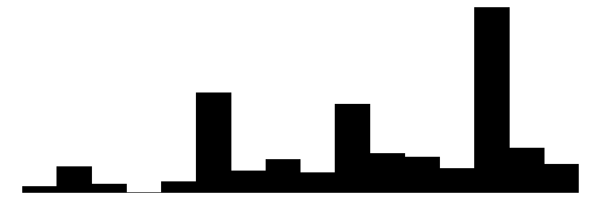

tchid

324

0

21099658.9

3844834.2

11203801.0

21653601.0

26494505.0

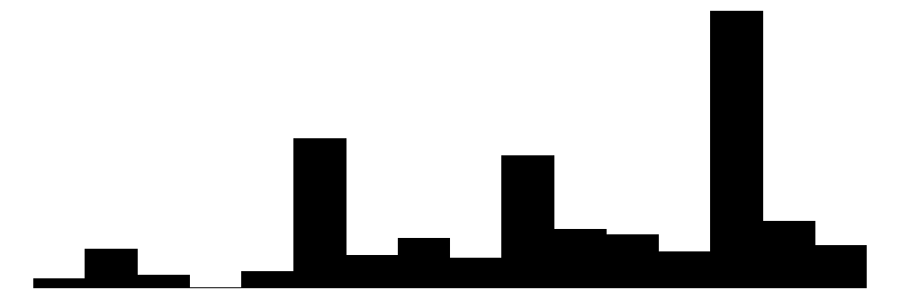

tchexper

25

0

9.3

5.8

0.0

9.0

27.0

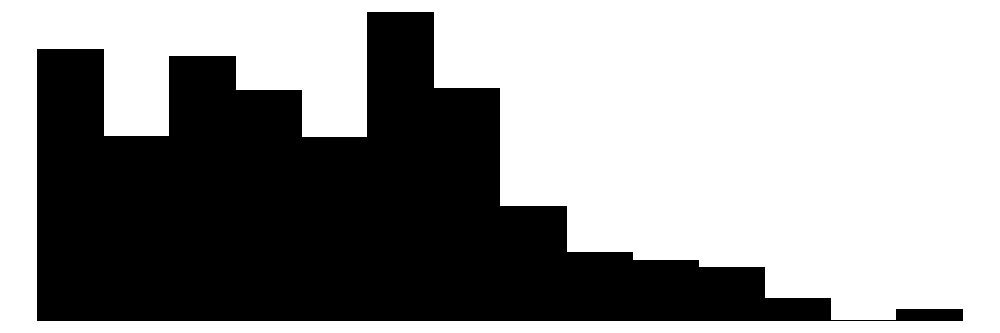

absent

69

0

10.3

9.3

0.0

8.0

79.0

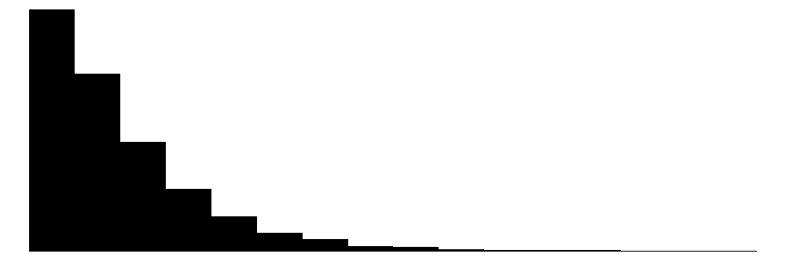

readscore

93

0

436.8

31.7

315.0

433.0

627.0

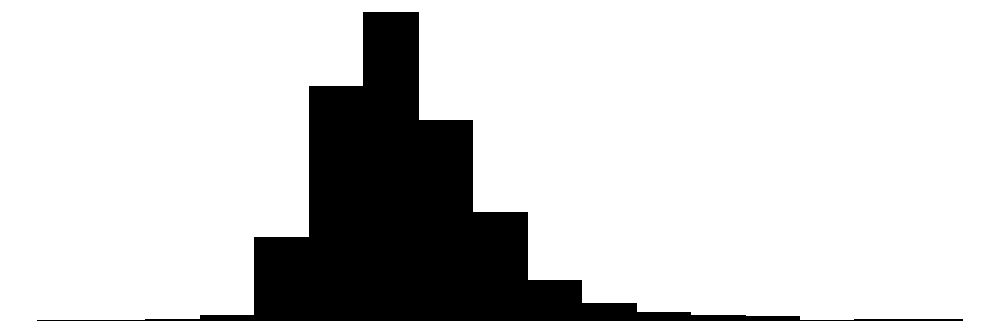

mathscore

37

0

485.7

47.7

320.0

484.0

626.0

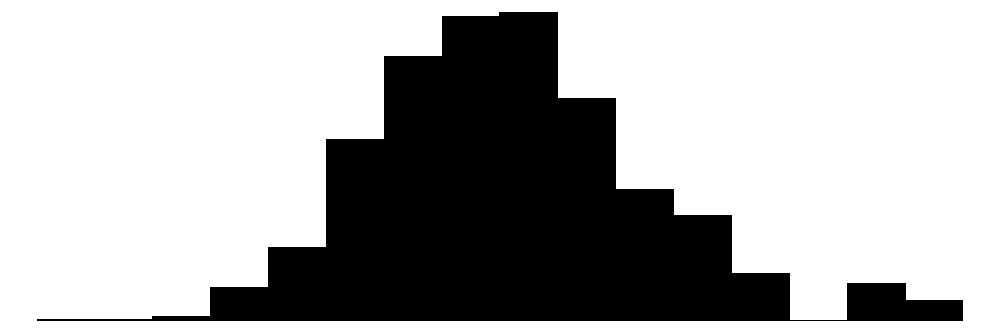

N

%

boy

0

2803

48.6

1

2963

51.4

white_asian

0

1871

32.4

1

3895

67.6

black

0

3909

67.8

1

1857

32.2

tchwhite

0

932

16.2

1

4834

83.8

tchmasters

0

3731

64.7

1

2035

35.3

freelunch

0

2990

51.9

1

2776

48.1

schurban

0

3976

69.0

1

1790

31.0

schrural

0

3041

52.7

1

2725

47.3

small

0

4028

69.9

1

1738

30.1

regular

0

3761

65.2

1

2005

34.8

aide

0

3743

64.9

1

2023

35.1

salas

aide

2023

35.1

small

1738

30.1

regular

2005

34.8

prof_exper

alta

422

7.3

media

2394

41.5

pouca

2950

51.2

##Tipos de salas

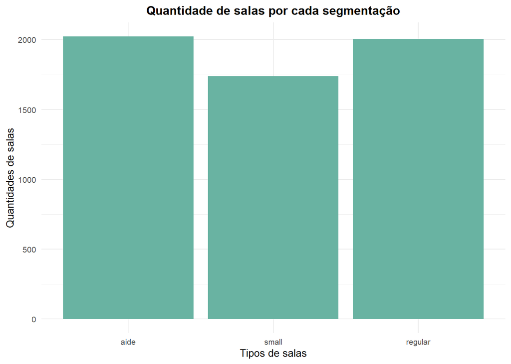

```r
#neste gráfico iremos verificar a quantidade de cada uma das três
#segmentações que o experimento apresentou
star %>%
  ggplot() +
  geom_bar(aes(x = salas, y= ..count..), fill = '#69b3a2') +
  theme_minimal() +
  labs(x = 'Tipos de salas',
       y = 'Quantidades de salas',
       title = 'Quantidade de salas por cada segmentação',) +
  theme(plot.title=element_text(size=12, face="bold", hjust =
                                0.5),
        legend.text=element_text(size=8),
        axis.text=element_text(size=8),
        axis.title = element_text(size = 10),
        legend.title = element_text(size = 10))
```

```r
summary(star$salas)
```

```
##    aide   small regular
##    2023    1738    2005
```

##descritivas por separação de sexo

[figure not shown]

```r
star %>%
  ggplot() +
  geom_bar(aes(x = as_factor(boy), y= ..count.., fill = salas), position = "dodge2") +
  theme_minimal() +
  labs(x = 'Tipos de salas',
       y = 'Quantidades de salas',
       title = 'Quantidade de salas por cada segmentação') +
  scale_x_discrete(labels = c('Menino', 'Menina')) +
  theme(plot.title=element_text(size=12, face="bold", hjust =
                                0.5),
        legend.text=element_text(size=8),
        axis.text=element_text(size=8),
        axis.title = element_text(size = 10),
        legend.title = element_text(size = 10))
```

```r
summary(star$mathscore[star$boy == 1])
```

```
##    Min. 1st Qu.  Median    Mean 3rd Qu.    Max.
##   320.0   449.0   478.0   481.9   513.0   626.0
```

```r
summary(star$mathscore[star$boy == 0])
```

```
##    Min. 1st Qu.  Median    Mean 3rd Qu.    Max.
##   320.0   459.0   484.0   489.6   520.0   626.0
```

##Analisando Mathscore para cada tipo de sala

```r
summary(star$mathscore[star$small == 1])
```

```
##    Min. 1st Qu.  Median    Mean 3rd Qu.    Max.
##   354.0   459.0   489.0   491.4   520.0   626.0
```

```r
summary(star$mathscore[star$regular == 1])
```

```
##    Min. 1st Qu.  Median    Mean 3rd Qu.    Max.
##   320.0   449.0   478.0   483.3   513.0   626.0
```

```r
summary(star$mathscore[star$aide == 1])
```

```
##    Min. 1st Qu.  Median    Mean 3rd Qu.    Max.
##     339     454     478     483     506     626
```

```r
summary(star$mathscore[star$prof_exper == 'pouca'])
```

```
##    Min. 1st Qu.  Median    Mean 3rd Qu.    Max.
##   320.0   449.0   478.0   481.9   513.0   626.0
```

```r
summary(star$mathscore[star$prof_exper == 'media'])
```

```
##    Min. 1st Qu.  Median    Mean 3rd Qu.    Max.
##   339.0   454.0   484.0   488.2   520.0   626.0
```

```r
summary(star$mathscore[star$prof_exper == 'alta'])
```

```
##    Min. 1st Qu.  Median    Mean 3rd Qu.    Max.
##   375.0   463.0   489.0   497.5   528.0   626.0
```

##analisando matscore para free luch

```r
summary(star$mathscore[star$freelunch == 0])
```

```
##    Min. 1st Qu.  Median    Mean 3rd Qu.    Max.
##   365.0   463.0   494.0   496.8   528.0   626.0
```

```r
summary(star$mathscore[star$freelunch == 1])
```

```
##    Min. 1st Qu.  Median    Mean 3rd Qu.    Max.
##   320.0   444.0   468.0   473.6   500.0   626.0
```

##analisando matscore para raça

```r
#notas de matemática se o aluno é preto ou não
summary(star$mathscore[star$black == 0])
```

```
##    Min. 1st Qu.  Median    Mean 3rd Qu.    Max.
##   320.0   459.0   489.0   491.4   520.0   626.0
```

```r
summary(star$mathscore[star$black == 1])
```

```
##    Min. 1st Qu.  Median    Mean 3rd Qu.    Max.
##   320.0   439.0   468.0   473.6   500.0   626.0
```

#regressões

```r
reg1 <- lm(mathscore ~ small + boy + freelunch + black + tchexper,
           data = star)
stargazer(reg1, type = "text")
```

```
##
## ===============================================
##                         Dependent variable:
##                     ---------------------------
##                              mathscore
## -----------------------------------------------
## small1                       8.118***
##                               (1.314)
##
## boy1                         -7.884***
##                               (1.206)
##
## freelunch1                  -19.428***
##                               (1.350)
##
## black1                       -7.717***
##                               (1.449)
##
## tchexper                     0.622***
##                               (0.105)
##
## Constant                    493.302***
##                               (1.562)
##
## -----------------------------------------------
## Observations                   5,766
## R2                             0.083
## Adjusted R2                    0.082
## Residual Std. Error     45.739 (df = 5760)
## F Statistic          103.854*** (df = 5; 5760)
## ===============================================
## Note:               *p<0.1; **p<0.05; ***p<0.01
```

#adicionando dummies

```r
#transformando a variável que identifica escola em dummie
star = star %>%
  mutate(
    schid = as_factor(schid)
  )
view(star)

#rodando a regressão com a identificação de escola como dummie
reg2 <- lm(mathscore ~ small + boy + freelunch + black + tchexper +
             schid, data = star)
stargazer(reg2, type = "text")
```

```
##
## ===============================================
##                         Dependent variable:
##                     ---------------------------
##                              mathscore
## -----------------------------------------------
## small1                       8.912***
##                               (1.197)
##
## boy1                         -6.676***
##                               (1.092)
##
## freelunch1                  -19.921***
##                               (1.321)
##
## black1                      -17.387***
##                               (2.342)
##
## tchexper                     0.392***
##                               (0.106)
##
## schid123056                   11.374
##                               (8.173)
##
## schid128068                    8.580
##                               (8.066)
##
## schid128076                    1.270
##                               (7.958)
##
## schid128079                   -2.051
##                               (7.887)
##
## schid130085                   12.407
##                               (7.594)
##
## schid159171                  48.934***
##                               (7.098)
##
## schid161176                   11.982
```

[output cut: 211 more lines]

```
##
## schid264945                  36.461***
##                               (7.206)
##
## Constant                    469.675***
##                               (6.033)
##
## -----------------------------------------------
## Observations                   5,766
## R2                             0.268
## Adjusted R2                    0.257
## Residual Std. Error     41.136 (df = 5682)
## F Statistic          25.076*** (df = 83; 5682)
## ===============================================
## Note:               *p<0.1; **p<0.05; ***p<0.01
```

```r
anova(reg2)
```

```
## Analysis of Variance Table
##
## Response: mathscore
##             Df  Sum Sq Mean Sq F value    Pr(>F)
## small        1   81943   81943  48.425 3.818e-12 ***
## boy          1   86677   86677  51.223 9.290e-13 ***
## freelunch    1  772662  772662 456.610 < 2.2e-16 ***
## black        1   71882   71882  42.479 7.760e-11 ***
## tchexper     1   73199   73199  43.257 5.229e-11 ***
## schid       78 2435583   31225  18.453 < 2.2e-16 ***
## Residuals 5682 9614912    1692
## ---
## Signif. codes:  0 '***' 0.001 '**' 0.01 '*' 0.05 '.' 0.1 ' ' 1
```

#regredindo para small

```r
#rodando a regressão tendo small como a variável de interesse
reg_small <- lm(as.numeric(small) ~ boy + freelunch + black + tchexper,
                data = star)

stargazer(reg_small, type = "text")
```

```
##
## ===============================================
##                         Dependent variable:
##                     ---------------------------
##                          as.numeric(small)
## -----------------------------------------------
## boy1                          -0.0003
##                               (0.012)
##
## freelunch1                    -0.008
##                               (0.014)
##
## black1                        -0.015
##                               (0.015)
##
## tchexper                     -0.003***
##                               (0.001)
##
## Constant                     1.338***
##                               (0.015)
##
## -----------------------------------------------
## Observations                   5,766
## R2                             0.002
## Adjusted R2                    0.001
## Residual Std. Error      0.459 (df = 5761)
## F Statistic           2.414** (df = 4; 5761)
## ===============================================
## Note:               *p<0.1; **p<0.05; ***p<0.01
```

```r
#verificando a aleatorização
aleatorizacao = glm(small ~ boy + freelunch + black + tchexper,
                    family=binomial(link="probit"), data = star)

stargazer(aleatorizacao, type = "text")
```

```
##
## =============================================
##                       Dependent variable:
##                   ---------------------------
##                              small
## ---------------------------------------------
## boy1                        -0.001
##                             (0.035)
##
## freelunch1                  -0.023
##                             (0.039)
##
## black1                      -0.045
##                             (0.042)
##
## tchexper                   -0.009***
##                             (0.003)
##
## Constant                   -0.414***
##                             (0.043)
##
## ---------------------------------------------
## Observations                 5,766
## Log Likelihood            -3,524.263
## Akaike Inf. Crit.          7,058.525
## =============================================
## Note:             *p<0.1; **p<0.05; ***p<0.01
```